# PML-project: Prediction Assignment Submission

Zack Zox

24 décembre, 2015

# 1 Background

Devices such as Jawbone Up, Nike FuelBand, and Fitbit are used to collect data about personal activity. Six participants were asked to perform one set of 10 repetitions of the Unilateral Dumbbell Biceps Curl in 5 different ways. The objective is to find how well the movements were done. The five ways (A:right and B-C-D-E:wrong) are:

- A- exactly according to the specification
- B- throwing the elbows to the front
- C- lifting the dumbbell only halfway
- D- lowering the dumbbell only halfway
- E- throwing the hips to the front

# 2 Data

## 2.1 Description

Data from accelerometers on the belt, forearm, arm, and dumbell of the participants were sampled (at frequency of 45Hz) during the whole sequence, with identification of the class of movement for each sampling. Prediction of exercise class must be done only with data from one sampling (no complete movement present in the test data set).

- **Training data** set has 19 622 observations with 159 variables. This is an average of 65 samplings during each of the 300 movements (6 participants x 5 types x 10 repetitions). Following is the breakdown of the samplings by classes.

```
   A    B    C    D    E
5580 3797 3422 3216 3607
```

- **Testing data** set has 20 samplings on the same 159 variables.

## 2.2 Features identification

- The first 6 columns are used for sampling identification and are removed from the features list.
- Many features have missing values both in the testing set and in the training set. Following figure shows distribution of missing columns for testing set. Same situation for the training set. Features with missing values are removed. (A feature was removed if more than 90% of its values are missing.) A test was done on the remaining features for near-zero-variation values. None was found.
- All features were centered and scaled on the training set. Same operations with same parameters were applied on the test set.

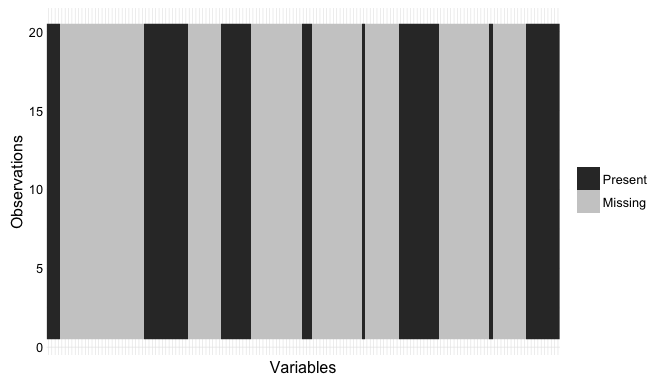

- We have 52 features available for modelling.

# 3 Model building

We supposed that there would be many intersections between samplings of different classes of movement and classification for these cases would be difficult. We planned to use a non-linear model that allows interactions. We selected « random forest » as the method of prediction. It was successful, so we did not test any other model. Since the classes are well balanced, we used *accuracy* as a measure of model performance.

In random forests, there is less need for cross-validation or a separate test set to get an unbiased estimate of the test set error, since it is estimated internally, during the run. The unbiased generalization error is calculated on out-of-bag (OOB) samples (about one third of the samples) not used in the bootstrap sample from the original data for each tree. (from documentation)

But to verify this assertion, we decided to split the samplings into two sets: *training* (60%) and *validation* (40%). Prediction on the validation set will be calculated.

## 3.1 Parameters tuning

```
Random Forest

11776 samples
   52 predictor
    5 classes: 'A', 'B', 'C', 'D', 'E'

No pre-processing
Resampling: Cross-Validated (10 fold)
Summary of sample sizes: 10599, 10600, 10599, 10600, 10597, 10599, ...
Resampling results across tuning parameters:

  mtry  Accuracy   Kappa      Accuracy SD  Kappa SD
   3    0.9921036  0.9900107  0.003663957  0.004635890
   7    0.9926124  0.9906544  0.002563325  0.003243682
  10    0.9914233  0.9891497  0.002448800  0.003098337
  14    0.9912539  0.9889358  0.004058899  0.005134395

Accuracy was used to select the optimal model using  the largest value.
The final value used for the model was mtry = 7.
```

## 3.2 Model validation

### 3.2.1 OOB error

Final model has an Out-Of-Bag error rate of 0.8% on the training set. This OOB error is a good estimate of the generalization error.

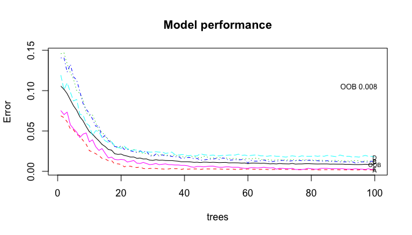

### 3.2.2 Validation set error

How accurately can we generalize on the validation set? Using the final model, we predicted the classes on the validation set to get an independent assessment of model accuracy. We have a 0.7% error rate (99.3% accuracy) for the validation set. So we are confident with the model built.

```
Confusion Matrix and Statistics

          Reference
Prediction    A    B    C    D    E
         A 2229    9    0    0    0
         B    2 1506   10    0    0
         C    0    3 1353   18    0
         D    0    0    5 1266    2
         E    1    0    0    2 1440

Overall Statistics

               Accuracy : 0.9934
                 95% CI : (0.9913, 0.995)
    No Information Rate : 0.2845
    P-Value [Acc > NIR] : < 2.2e-16

                  Kappa : 0.9916
 Mcnemar's Test P-Value : NA

Statistics by Class:

                     Class: A Class: B Class: C Class: D Class: E
Sensitivity            0.9987   0.9921   0.9890   0.9844   0.9986
Specificity            0.9984   0.9981   0.9968   0.9989   0.9995
Pos Pred Value         0.9960   0.9921   0.9847   0.9945   0.9979
Neg Pred Value         0.9995   0.9981   0.9977   0.9970   0.9997
Prevalence             0.2845   0.1935   0.1744   0.1639   0.1838
Detection Rate         0.2841   0.1919   0.1724   0.1614   0.1835
Detection Prevalence   0.2852   0.1935   0.1751   0.1622   0.1839
Balanced Accuracy      0.9985   0.9951   0.9929   0.9917   0.9991
```

# 4 Prediction on the test set

Finally, the prediction model was run on the test data to predict the classes for the 20 test cases and the submission files were created.

```r
(testingPred <- predict(rf_model, testing ))
```

```
 [1] B A B A A E D B A A B C B A E E A B B B
Levels: A B C D E
```